GDAA 2010 | Dr. Steven Edwards | George Lee Tannous

# Assignment #2 Applied Deep Learning using TensorFlow

## What is TensorFlow?

TensorFlow is an open-source machine learning library developed by Google that provides a powerful platform for building and training different types of machine learning models, including neural networks. It allows you to create, train and evaluate complex models for tasks such as image and speech recognition, natural language processing, and more. Assignemnt #2 will take a deeper focus on exploring the capabilites of tensor flow by generating label predictions (classifications) for a set of web scraped images.

### How does TensorFlow Work?

TensorFlow works by creating a "graph" that represents the structure of a machine learning model. This graph is made up of nodes, which represent mathematical operations, and edges, which represent the flow of data between these operations. To create the graph, you define the input and output data, and then add layers and operations that manipulate the data in a specific way. Once the graph is defined, you can train the model by adjusting the weights of the layers to minimize the error between the predicted output and the actual output. After the model has been trained, you can use it to predict outcomes from new data. TensorFlow is designed to efficiently perform these computations on large datasets, and it also offers features for distributed computing to speed up the training process on multiple devices.

### The Scenario for Assignmet #2

To celebrate the Masters golf tournament happening this month, I will be utilizing TensorFlow to generate label predictions for different golf clubs! The objective is to accurately distinguish between "irons" and "drivers" based on their visual features, using two sets of images. The images may vary in size, resolution, and complexity, and may contain multiple objects or backgrounds. Once the model is trained, it can be used to make predictions on new images, enabling automatic classification and categorization of large datasets of images related to golf clubs.

To gather these images from the web, I've made use of the Google Chrome extension called 'Download All Images.

```
Image Count Golf Irons: 344
Image Count Gold Driver: 306
```

**Assignmenmnt #2, will not implement the use of a GPU.**

## Step 1. Load and Preprocess the Image Data

```python
# Importing TensorFlow and required packages
import tensorflow as tf
import os
import cv2
import imghdr
import numpy as np
from matplotlib import pyplot as plt
```

```python
# Specifying the folder location where your data is stored.
data_dir = 'data'

# The image extensions that will be using.
image_exts = ['jpeg', 'jpg', 'bmp', 'png']

for image_class in os.listdir(data_dir):
    for image in os.listdir(os.path.join(data_dir, image_class)):
        image_path = os.path.join(data_dir, image_class, image)
        try:
            img = cv2.imread(image_path)
            img_type = imghdr.what(image_path)
            if img_type not in image_exts:
                print('Removing image not in extension list: {}'.format(image_path))
                os.remove(image_path)
            else:
                print('Image in extension list: {}'.format(image_path))
        except Exception as e:
            print('Issue with image {}: {}'.format(image_path, str(e)))
```

[output not shown]

[output cut: 542 more lines]

[output not shown]

This code loops through each directory in data_dir, then loops through each image in the directory, checking if the image has an extension that is in the image_exts list. If the image does not have an extension that is in the list, it will be removed. If the image has an extension that is in the list, it will not be removed.

```python
# Loading in webscraped images located in 'data'.
data = tf.keras.utils.image_dataset_from_directory('data')
```

```
Found 597 files belonging to 2 classes.
```

```python
data_iterator = data.as_numpy_iterator()
batch = data_iterator.next()
```

The code loads an image dataset using TensorFlow and creates an iterator from it. The as_numpy_iterator() method converts the TensorFlow dataset to a NumPy array iterator. The next() method is called on the iterator to get the first batch of data from the dataset. This can be useful for inspecting the data or for passing it to a machine learning model for training.

[figure not shown]

```python
fig, ax = plt.subplots(ncols = 4, figsize=(20,20))
for idx, img in enumerate(batch[0][:4]):
    ax[idx].imshow(img.astype(int))
    ax[idx].title.set_text(batch[1][idx])
```

## 3. Making the Image Size Consistent by Rescaling

Rescaling images for TensorFlow is necessary to ensure consistency in the input data that is fed into the deep learning model. By rescaling the images to a uniform size, we can also reduce the memory usage and computational cost of the model. Additionally, rescaling the images can be part of the preprocessing pipeline, which can include other operations such as normalization, cropping, and augmentation, to improve the quality and diversity of the data and subsequently improve the accuracy and generalization of the model. In summary, rescaling images is an essential step in preparing the image data for deep learning models.

```python
data = data.map(lambda x,y: (x/255, y))
data.as_numpy_iterator().next()
```

[output not shown]

[output cut: 254 more lines]

[output not shown]

## 4. Generating Splits of Data for Training, Validation, and Testing

```python
# establish the training/validation/test split proportions
train_size = int(len(data)*0.7)
val_size = int(len(data)*0.2)
test_size = int(len(data)*0.1)
```

```python
# creating train, validation, and test datasets
train = data.take(train_size)
val = data.skip(train_size).take(val_size)
test = data.skip(train_size+val_size).take(test_size)
```

# 5. Deep Learning Model Training

```python
# First, let's import the specific modules we need from TF
from tensorflow.keras.models import Sequential
from tensorflow.keras.callbacks import EarlyStopping
from tensorflow.keras.layers import Conv2D, MaxPooling2D, Dense, Flatten, Dropout
```

```python
# now, let's instantiate the blank model
model = Sequential()

model.add(Conv2D(16, (3,3), activation='relu', input_shape = (256,256,3)))
model.add(MaxPooling2D())
model.add(Flatten())
model.add(Dense(64, activation='relu'))
model.add(Dense(1, activation='sigmoid'))
```

The model layers were established above and went through multiple revisions to achieve an optimal design. The initial model was more complex, featuring multiple convolutional layers, max pooling layers, a flatten layer, and two dense layers. However, after training for a larger number of epochs, it was observed that the model started overfitting. In order to prevent overfitting and reduce the complexity of the model, the number of convolutional and dense layers were reduced. The final model consisted of only one convolutional layer, a max pooling layer, a flatten layer, and two dense layers. This simpler architecture achieved a good balance between model complexity and generalization performance, resulting in improved accuracy on the test set.

We selected a convolutional neural network (CNN) architecture consisting of a single convolutional layer with 16 filters of size 3x3, followed by a max pooling layer to downsample the feature maps. The output was then flattened and passed through two fully connected layers, with 64 and 1 units respectively, and ReLU activation function. Finally, a sigmoid activation function was used to produce a binary classification output. This architecture strikes a balance between complexity and generalization performance, allowing us to effectively classify golf clubs from images.

```python
# Defining the evaluation metrics for the model.
model.compile('adam', loss=tf.losses.BinaryCrossentropy(), metrics=['accuracy'])
```

```python
# Let us generate the summary of the model configuration before we initiate the training process.
model.summary()
```

```
Model: "sequential_1"
_________________________________________________________________
 Layer (type)                Output Shape              Param #
=================================================================
 conv2d_1 (Conv2D)           (None, 254, 254, 16)      448

 max_pooling2d_1 (MaxPooling  (None, 127, 127, 16)     0
 2D)

 flatten_1 (Flatten)         (None, 258064)            0

 dense_2 (Dense)             (None, 64)                16516160

 dense_3 (Dense)             (None, 1)                 65

=================================================================
Total params: 16,516,673
Trainable params: 16,516,673
Non-trainable params: 0
_________________________________________________________________
```

# 6. Train and Validate the Deep Learning Model

```python
logdir = 'logs'
```

```python
# TensorBoard callback for monitoring the training process
tensorboard_callback = tf.keras.callbacks.TensorBoard(log_dir=logdir)
```

```python
# Train the model for 10 epochs using the training data and validation data for evaluation, with TensorBoard logging callbacks.
# The training progress and metrics will be recorded and visualized using TensorBoard.
hist = model.fit(train, epochs=10, validation_data=val, callbacks=[tensorboard_callback])
```

```python
# Testing accuracy of model
test_loss, test_acc = model.evaluate(train, verbose=2)

print('\nTest accuracy:', test_acc)
```

```
13/13 - 2s - loss: 0.0763 - accuracy: 0.9784 - 2s/epoch - 164ms/step

Test accuracy: 0.9783653616905212
```

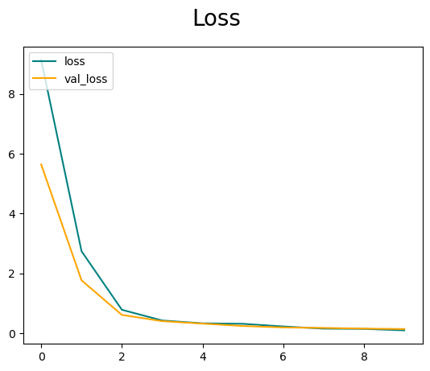

```python
fig = plt.figure()
plt.plot(hist.history['loss'], color = 'teal', label = 'loss')
plt.plot(hist.history['val_loss'], color = 'orange', label = 'val_loss')
fig.suptitle('Loss', fontsize=20)
plt.legend(loc='upper left')
plt.show()
```

During the training process, a loss metric was used to monitor the model's performance. The model was trained for 10 epochs, and the loss metric showed consistent improvement without any signs of overfitting. However, when the model was trained for 20 epochs, the loss metric indicated that the model had started to overfit. Therefore, the number of epochs was readjusted to 10, and the model was trained again. The readjustment led to a better training of the model, and the loss metric continued to show improvement without overfitting. Observing that both the training loss and validation loss decrease and stabilize at a similar point.

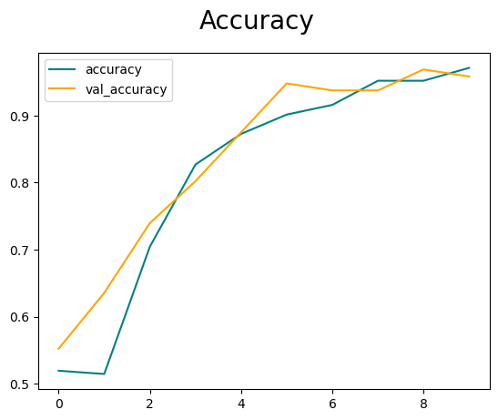

```python
fig = plt.figure()
plt.plot(hist.history['accuracy'], color = 'teal', label = 'accuracy')
plt.plot(hist.history['val_accuracy'], color = 'orange', label = 'val_accuracy')
fig.suptitle('Accuracy', fontsize=20)
plt.legend(loc='upper left')
plt.show()
```

```python
# select an image (not one that was included in the training)
img = cv2.imread('george_driver.jpeg')
```

plt.imshow(img) plt.show()

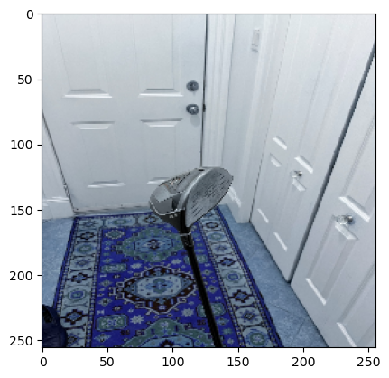

```python
resize = tf.image.resize(img, (256,256))
plt.imshow(resize.numpy().astype(int))
plt.show()
```

```python
predicted = model.predict(np.expand_dims(resize/255, 0))
```

```python
predicted
```

```
array([[0.14536935]], dtype=float32)
```

```python
if predicted > 0.5:
    print(f'Predicted class is an Iron')
else:
    print(f'Predicted class is an Driver')
```

```
Predicted class is an Driver
```

```python
# select an image (not one that was included in the training)
img = cv2.imread('george_irons.jpeg')
```

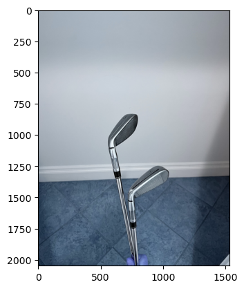

```python
plt.imshow(img)
plt.show()
```

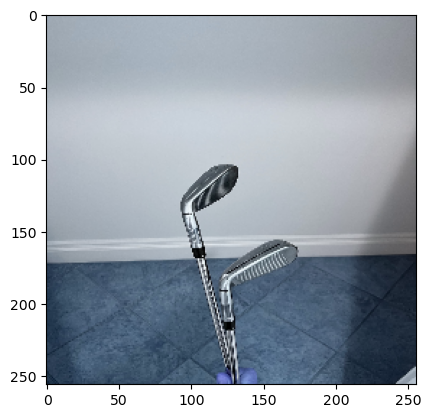

```python
resize = tf.image.resize(img, (256,256))
plt.imshow(resize.numpy().astype(int))
plt.show()
```

```python
predicted = model.predict(np.expand_dims(resize/255, 0))
```

```python
predicted
```

```
array([[0.88216436]], dtype=float32)
```

```python
if predicted > 0.5:
    print(f'Predicted class is an Iron')
else:
    print(f'Predicted class is an Driver')
```

```
Predicted class is an Iron
```

```python
test_loss, test_accuracy = model.evaluate(test)

print('Test loss: ', test_loss)
print('Test accuracy: ', test_accuracy)
```

```
Test loss:  0.03230835497379303
Test accuracy:  1.0
```

# 4. Save/Export Model¶

```python
from tensorflow.keras.models import load_model
```

```python
model.save(os.path.join('models','Golf_Club_Classifier.h5'))
```

This line of code saves the trained machine learning model to a file named "Golf_Club_Classifier.h5" in a directory called "models". The ".h5" file extension indicates that the file is in the Hierarchical Data Format (HDF5) format, which is commonly used for storing large and complex data. Saving the trained model allows us to reuse it later without having to retrain it from scratch.

```python
# loading in saved model "Golf_Club_Classifier"
new_model = load_model(os.path.join('models','Golf_Club_Classifier.h5'))
```

```python
new_prediction = new_model.predict(np.expand_dims(resize/255, 0))
```

```python
if predicted > 0.5:
    print(f'Predicted class is an Iron')
else:
    print(f'Predicted class is an Driver')
```

[output not shown]

# 5. Conclusion

In conclusion, we have discussed various aspects of training a deep learning model for image classification, specifically on the classification of golf clubs, including irons and drivers. We established the model architecture by carefully selecting the appropriate layers and activation functions and made revisions to optimize the model's performance. We created train, validation, and test datasets to properly evaluate the model. We also utilized callbacks such as TensorBoard for monitoring and analysis during training. Finally, we analyzed accuracy and validation accuracy graphs to assess the model's performance in classifying golf clubs. By analyzing accuracy and validation accuracy graphs, we assessed the model's performance in accurately classifying golf clubs.